# Credit Risk Analysis Usign Logistic Regression

Dr. Juliho Castillo

6 de septiembre de 2018

# Introduction and data preprocessing

## The Data

```r
loan_data <- readRDS("./data/loan_data_ch1.rds")
head(loan_data,10)
```

```
##    loan_status loan_amnt int_rate grade emp_length home_ownership
## 1            0      5000    10.65     B         10           RENT
## 2            0      2400       NA     C         25           RENT
## 3            0     10000    13.49     C         13           RENT
## 4            0      5000       NA     A          3           RENT
## 5            0      3000       NA     E          9           RENT
## 6            0     12000    12.69     B         11            OWN
## 7            1      9000    13.49     C          0           RENT
## 8            0      3000     9.91     B          3           RENT
## 9            1     10000    10.65     B          3           RENT
## 10           0      1000    16.29     D          0           RENT
##    annual_inc age
## 1       24000  33
## 2       12252  31
## 3       49200  24
## 4       36000  39
## 5       48000  24
## 6       75000  28
## 7       30000  22
## 8       15000  22
## 9      100000  28
## 10      28000  22
```

## CrossTable

```r
library(gmodels)
CrossTable(loan_data$home_ownership)
```

```
##
##
##    Cell Contents
## |-------------------------|
## |                       N |
## |         N / Table Total |
## |-------------------------|
##
##
## Total Observations in Table:  29092
##
##
##           |  MORTGAGE |     OTHER |       OWN |      RENT |
##           |-----------|-----------|-----------|-----------|
##           |     12002 |        97 |      2301 |     14692 |
##           |     0.413 |     0.003 |     0.079 |     0.505 |
##           |-----------|-----------|-----------|-----------|
##
##
##
##
```

```r
CrossTable(loan_data$home_ownership, loan_data$loan_status, prop.r = TRUE,
           prop.c = FALSE, prop.t = FALSE, prop.chisq = FALSE)
```

```
##
##
##    Cell Contents
## |-------------------------|
## |                       N |
## |           N / Row Total |
## |-------------------------|
##
##
## Total Observations in Table:  29092
##
##
##                          | loan_data$loan_status
## loan_data$home_ownership |         0 |         1 | Row Total |
## -------------------------|-----------|-----------|-----------|
##                 MORTGAGE |     10821 |      1181 |     12002 |
##                          |     0.902 |     0.098 |     0.413 |
## -------------------------|-----------|-----------|-----------|
##                    OTHER |        80 |        17 |        97 |
##                          |     0.825 |     0.175 |     0.003 |
## -------------------------|-----------|-----------|-----------|
##                      OWN |      2049 |       252 |      2301 |
##                          |     0.890 |     0.110 |     0.079 |
## -------------------------|-----------|-----------|-----------|
##                     RENT |     12915 |      1777 |     14692 |
##                          |     0.879 |     0.121 |     0.505 |
## -------------------------|-----------|-----------|-----------|
##             Column Total |     25865 |      3227 |     29092 |
## -------------------------|-----------|-----------|-----------|
##
##
```

### Exploring the credit data

View the structure of loan_data

```r
library(dplyr)
glimpse(loan_data)
```

```
## Observations: 29,092
## Variables: 8
## $ loan_status    <int> 0, 0, 0, 0, 0, 0, 1, 0, 1, 0, 0, 0, 0, 0, 1, 0,...
## $ loan_amnt      <int> 5000, 2400, 10000, 5000, 3000, 12000, 9000, 300...
## $ int_rate       <dbl> 10.65, NA, 13.49, NA, NA, 12.69, 13.49, 9.91, 1...
## $ grade          <fct> B, C, C, A, E, B, C, B, B, D, C, A, B, A, B, B,...
## $ emp_length     <int> 10, 25, 13, 3, 9, 11, 0, 3, 3, 0, 4, 13, 1, 6, ...
## $ home_ownership <fct> RENT, RENT, RENT, RENT, RENT, OWN, RENT, RENT, ...
## $ annual_inc     <dbl> 24000.00, 12252.00, 49200.00, 36000.00, 48000.0...
## $ age            <int> 33, 31, 24, 39, 24, 28, 22, 22, 28, 22, 23, 27,...
```

Call CrossTable() on loan_status

```r
CrossTable(loan_data$loan_status)
```

```
##
##
##    Cell Contents
## |-------------------------|
## |                       N |
## |         N / Table Total |
## |-------------------------|
##
##
## Total Observations in Table:  29092
##
##
##           |         0 |         1 |
##           |-----------|-----------|
##           |     25865 |      3227 |
##           |     0.889 |     0.111 |
##           |-----------|-----------|
##
##
##
##
```

Call CrossTable() on grade and loan_status

```r
CrossTable(loan_data$grade, loan_data$loan_status, prop.r=T, prop.c=F, prop.t=F, prop.chisq=F)
```

```
##
##
##    Cell Contents
## |-------------------------|
## |                       N |
## |           N / Row Total |
## |-------------------------|
##
##
## Total Observations in Table:  29092
##
##
##                 | loan_data$loan_status
## loan_data$grade |         0 |         1 | Row Total |
## ----------------|-----------|-----------|-----------|
##               A |      9084 |       565 |      9649 |
##                 |     0.941 |     0.059 |     0.332 |
## ----------------|-----------|-----------|-----------|
##               B |      8344 |       985 |      9329 |
##                 |     0.894 |     0.106 |     0.321 |
## ----------------|-----------|-----------|-----------|
##               C |      4904 |       844 |      5748 |
##                 |     0.853 |     0.147 |     0.198 |
## ----------------|-----------|-----------|-----------|
##               D |      2651 |       580 |      3231 |
##                 |     0.820 |     0.180 |     0.111 |
## ----------------|-----------|-----------|-----------|
##               E |       692 |       176 |       868 |
##                 |     0.797 |     0.203 |     0.030 |
## ----------------|-----------|-----------|-----------|
##               F |       155 |        56 |       211 |
##                 |     0.735 |     0.265 |     0.007 |
## ----------------|-----------|-----------|-----------|
##               G |        35 |        21 |        56 |
##                 |     0.625 |     0.375 |     0.002 |
## ----------------|-----------|-----------|-----------|
##    Column Total |     25865 |      3227 |     29092 |
## ----------------|-----------|-----------|-----------|
##
##
```

The proportion of defaults increases when the credit rating moves from A to G

## Histogram and outliers

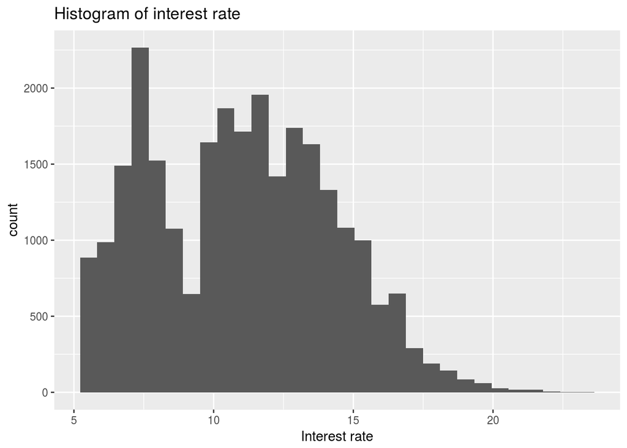

```r
library(ggplot2)
ggplot(loan_data, aes(x=int_rate)) +
  geom_histogram( ) +
  ggtitle("Histogram of interest rate") +
  xlab("Interest rate")
```

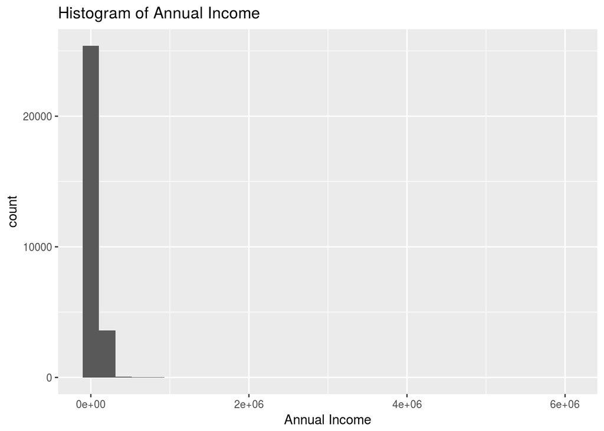

```r
ggplot(loan_data, aes(x=annual_inc)) +
  geom_histogram() +
  xlab("Annual Income") +
  ggtitle("Histogram of Annual Income")
```

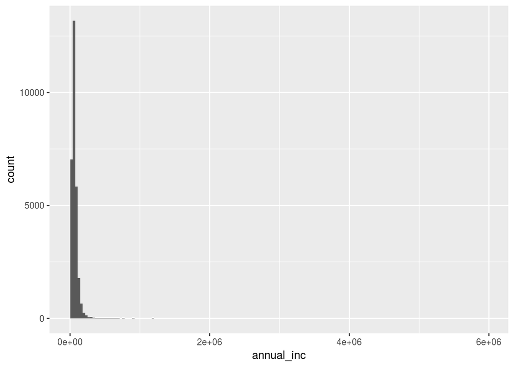

```r
n_ <- sqrt(nrow(loan_data))
m = min(loan_data$annual_inc)
M = max(loan_data$annual_inc)
n_breaks = seq(m,M,(M-m)/(n_-1))

hist_income_n <- ggplot(loan_data, aes(x=annual_inc)) +
  geom_histogram(breaks=n_breaks )

hist_income_n
```

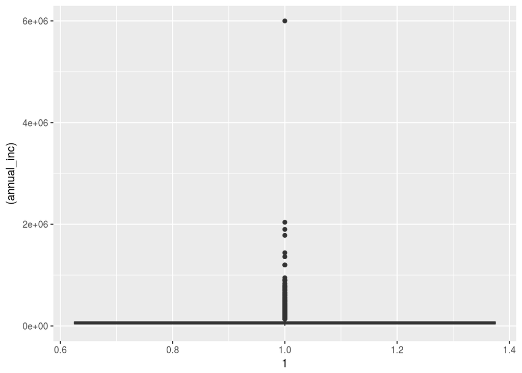

```r
ggplot(loan_data, aes(x=1, y=(annual_inc))) +
  geom_boxplot()
```

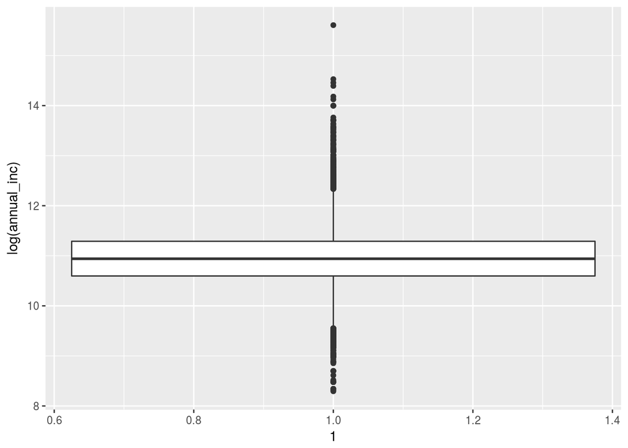

```r
ggplot(loan_data, aes(x=1, y=log(annual_inc))) +
  geom_boxplot()
```

Expert judgement vs Rule Of Thum

- “Annual salaries > $ 3 million are outliers”

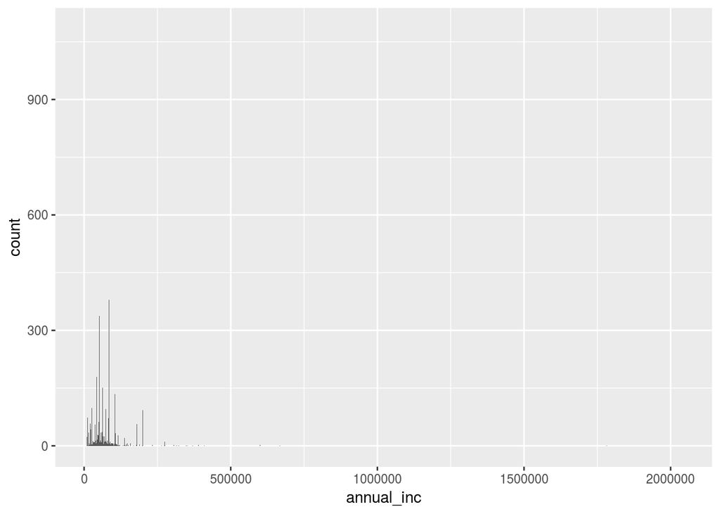

```r
loan_data_expert <- loan_data %>%
  filter(annual_inc <= 3*10^6)

n = nrow(loan_data_expert)
l = sqrt(n)

ggplot(loan_data_expert, aes(x = annual_inc)) +
  geom_histogram(binwidth = l)
```

- Use of a rule of thumb: outlier if bigger than Q3 + 1.5 * IQR

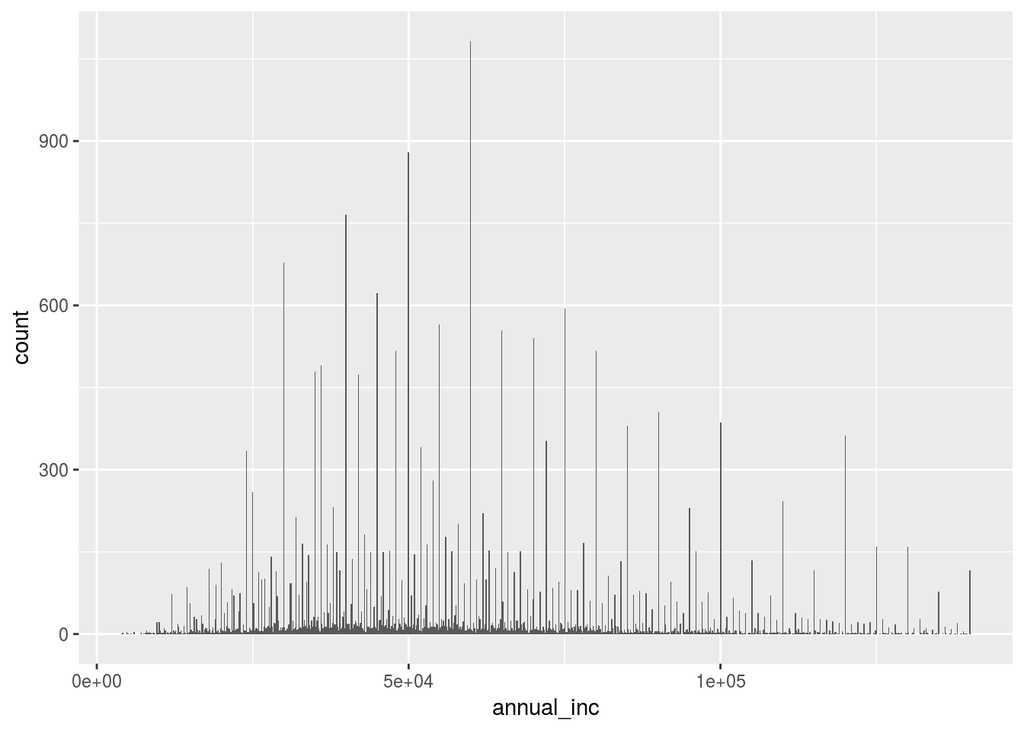

```r
outlier_cutoff <- quantile(loan_data$annual_inc, 0.75) + 1.5*IQR(loan_data$annual_inc)

loan_data_ROT <- loan_data %>%
  filter(annual_inc <= outlier_cutoff)

n = nrow(loan_data_ROT)
l = sqrt(n)


ggplot(loan_data_ROT, aes(x = annual_inc)) +
  geom_histogram(binwidth = l)
```

## Missing Data and Coarse Classifitacion

```r
summary(loan_data_ROT)
```

```
##   loan_status       loan_amnt        int_rate     grade
##  Min.   :0.0000   Min.   :  500   Min.   : 5.42   A:9255
##  1st Qu.:0.0000   1st Qu.: 5000   1st Qu.: 7.90   B:8859
##  Median :0.0000   Median : 8000   Median :10.99   C:5501
##  Mean   :0.1123   Mean   : 9283   Mean   :10.98   D:3062
##  3rd Qu.:0.0000   3rd Qu.:12000   3rd Qu.:13.47   E: 795
##  Max.   :1.0000   Max.   :35000   Max.   :23.22   F: 188
##                                   NA's   :2648    G:  50
##    emp_length      home_ownership    annual_inc          age
##  Min.   : 0.000   MORTGAGE:11055   Min.   :  4000   Min.   :20.00
##  1st Qu.: 2.000   OTHER   :   91   1st Qu.: 39000   1st Qu.:23.00
##  Median : 4.000   OWN     : 2202   Median : 55000   Median :26.00
##  Mean   : 6.063   RENT    :14362   Mean   : 59570   Mean   :27.57
##  3rd Qu.: 8.000                    3rd Qu.: 75000   3rd Qu.:30.00
##  Max.   :62.000                    Max.   :140000   Max.   :94.00
##  NA's   :795
```

```r
#### me!
#loan_data <- loan_data_ROT
loan_data <- loan_data_expert
####
summary(loan_data$emp_length)
```

```
##    Min. 1st Qu.  Median    Mean 3rd Qu.    Max.    NA's
##   0.000   2.000   4.000   6.145   8.000  62.000     809
```

```r
nrow(loan_data)
```

```
## [1] 29091
```

### Missing inputs: strategies

- Delete row/column
- Replace
- Keep

### Delete rows

```r
index_NA <- which(is.na(loan_data$emp_length))
loan_data_no_NA <- loan_data[-c(index_NA), ]
```

### Delete column

```r
loan_data_delete_employ <- loan_data
loan_data_delete_employ$emp_length <- NULL
```

### Replace: median imputation

```r
index_NA <- which(is.na(loan_data$emp_length))
loan_data_replace <- loan_data
loan_data_replace$emp_length[index_NA] <- median(loan_data$emp_length, na.rm = TRUE)
```

### Keep!!!

```r
my_func <- function(x) {
  if (is.na(x)) {
    return("Missing")
  } else if(0<=x & x<15) {
    return("0-15")
  } else if(15<=x & x<30) {
    return("15-30")
  } else if(30<=x & x<45) {
    return("30-45")
  } else {
    return("45+")
  }

}

temp <- loan_data$emp_length
#print(temp)
loan_data$emp_length <- NULL
print(loan_data$emp_lenght)
```

```r
loan_data$emp_cat <- sapply(temp, my_func)
loan_data$emp_cat <- as.factor(loan_data$emp_cat)

str(loan_data)
```

```
## 'data.frame':    29091 obs. of  8 variables:
##  $ loan_status   : int  0 0 0 0 0 0 1 0 1 0 ...
##  $ loan_amnt     : int  5000 2400 10000 5000 3000 12000 9000 3000 10000 1000 ...
##  $ int_rate      : num  10.7 NA 13.5 NA NA ...
##  $ grade         : Factor w/ 7 levels "A","B","C","D",..: 2 3 3 1 5 2 3 2 2 4 ...
##  $ home_ownership: Factor w/ 4 levels "MORTGAGE","OTHER",..: 4 4 4 4 4 3 4 4 4 4 ...
##  $ annual_inc    : num  24000 12252 49200 36000 48000 ...
##  $ age           : int  33 31 24 39 24 28 22 22 28 22 ...
##  $ emp_cat       : Factor w/ 5 levels "0-15","15-30",..: 1 2 1 1 1 1 1 1 1 1 ...
```

```r
summary(loan_data)
```

```
##   loan_status       loan_amnt        int_rate     grade
##  Min.   :0.0000   Min.   :  500   Min.   : 5.42   A:9649
##  1st Qu.:0.0000   1st Qu.: 5000   1st Qu.: 7.90   B:9329
##  Median :0.0000   Median : 8000   Median :10.99   C:5747
##  Mean   :0.1109   Mean   : 9594   Mean   :11.00   D:3231
##  3rd Qu.:0.0000   3rd Qu.:12250   3rd Qu.:13.47   E: 868
##  Max.   :1.0000   Max.   :35000   Max.   :23.22   F: 211
##                                   NA's   :2776    G:  56
##   home_ownership    annual_inc           age          emp_cat
##  MORTGAGE:12001   Min.   :   4000   Min.   :20.0   0-15   :25221
##  OTHER   :   97   1st Qu.:  40000   1st Qu.:23.0   15-30  : 2719
##  OWN     : 2301   Median :  56400   Median :26.0   30-45  :  307
##  RENT    :14692   Mean   :  66965   Mean   :27.7   45+    :   35
##                   3rd Qu.:  80000   3rd Qu.:30.0   Missing:  809
##                   Max.   :2039784   Max.   :94.0
##
```

### Deleting missing data

```r
# Look at summary of loan_data
print(summary(loan_data$int_rate))
```

```
##    Min. 1st Qu.  Median    Mean 3rd Qu.    Max.    NA's
##    5.42    7.90   10.99   11.00   13.47   23.22    2776
```

```r
# Get indices of missing interest rates: na_index
na_index <- which(is.na(loan_data$int_rate))

# Remove observations with missing interest rates: loan_data_delrow_na
loan_data_delrow_na <- loan_data[-na_index, ]
print(summary(loan_data_delrow_na$int_rate))
```

```
##    Min. 1st Qu.  Median    Mean 3rd Qu.    Max.
##    5.42    7.90   10.99   11.00   13.47   23.22
```

```r
# Make copy of loan_data
loan_data_delcol_na <- loan_data

# Delete interest rate column from loan_data_delcol_na
loan_data_delcol_na$int_rate <- NULL
print(summary(loan_data_delcol_na$int_rate))
```

```
## Length  Class   Mode
##      0   NULL   NULL
```

### Replacing missing data

```r
# Compute the median of int_rate
median_ir <- median(loan_data$int_rate, na.rm=T)

# Make copy of loan_data
loan_data_replace <- loan_data

# Replace missing interest rates with median
loan_data_replace$int_rate[na_index] <- median_ir

# Check if the NAs are gone
summary(loan_data_replace$int_rate)
```

```
##    Min. 1st Qu.  Median    Mean 3rd Qu.    Max.
##    5.42    8.49   10.99   11.00   13.11   23.22
```

### Keeping missing data

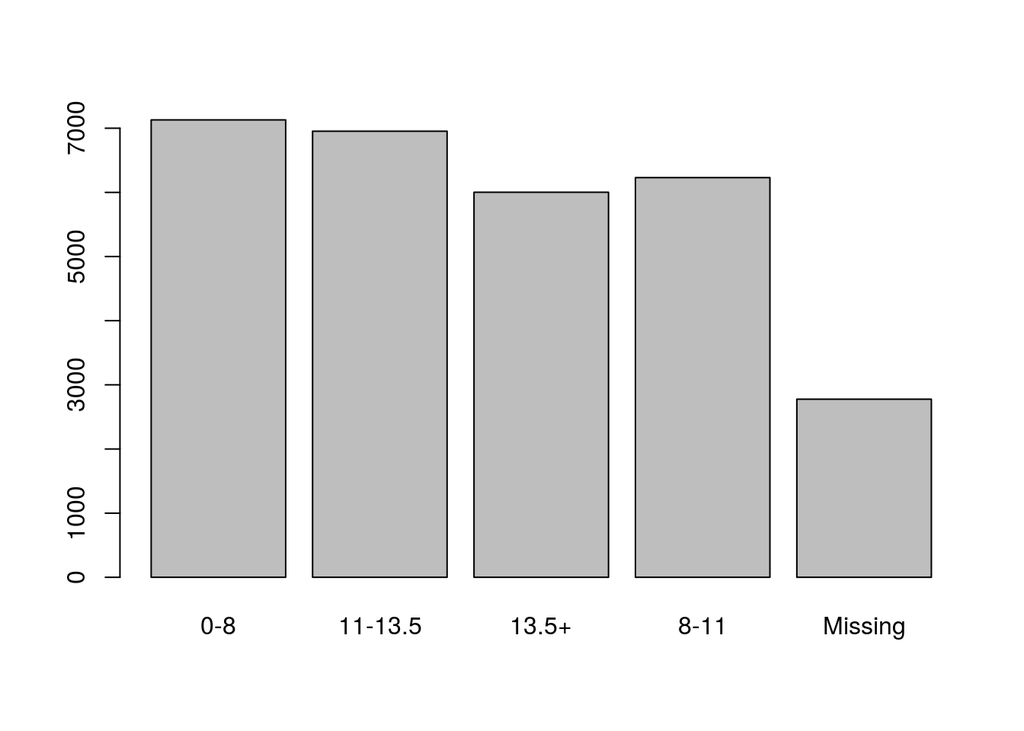

```r
# Make the necessary replacements in the coarse classification example below
loan_data$ir_cat <- rep(NA, length(loan_data$int_rate))

loan_data$ir_cat[which(loan_data$int_rate <= 8)] <- "0-8"
loan_data$ir_cat[which(loan_data$int_rate > 8 & loan_data$int_rate <= 11)] <- "8-11"
loan_data$ir_cat[which(loan_data$int_rate > 11 & loan_data$int_rate <= 13.5)] <- "11-13.5"
loan_data$ir_cat[which(loan_data$int_rate > 13.5)] <- "13.5+"
loan_data$ir_cat[which(is.na(loan_data$int_rate))] <- "Missing"

loan_data$ir_cat <- as.factor(loan_data$ir_cat)

# Look at your new variable using plot()
plot(loan_data$ir_cat)
```

```r
print(levels(loan_data$ir_cat))
```

```
## [1] "0-8"     "11-13.5" "13.5+"   "8-11"    "Missing"
```

```r
loan_data$int_rate <- NULL
```

## Data splitting and confusion matrices

### Splitting the data set

```r
# Set seed of 567
set.seed(567)

# Store row numbers for training set: index_train
index_train <- sample(1:nrow(loan_data), 2/3*nrow(loan_data))

# Create training set: training_set
training_set <- loan_data[index_train, ]

# Create test set: test_set
test_set <- loan_data[-index_train, ]
```

### Creating a confusion matrix

```r
#Simulate a model
X <- length(test_set$loan_status)
Dls <- sample(c(0,0,0,0,1), replace=TRUE, size=X)
model_pred <- test_set$loan_status+Dls

# Create confusion matrix
conf_matrix <- table(test_set$loan_status, model_pred)

# Compute classification accuracy
(conf_matrix[2,2]+conf_matrix[1,1])/sum(conf_matrix)
```

```
## [1] 0.8013819
```

```r
# Compute sensitivity
conf_matrix[2,2]/sum(conf_matrix[2,])
```

```
## [1] 0.780135
```

# Logistic regression

## Logistic regression: introduction

### Basic logistic regression

```r
# Build a glm model with variable ir_cat as a predictor
log_model_cat <- glm(loan_status ~ ir_cat, family = "binomial", data = training_set)


# Print the parameter estimates
log_model_cat
```

```
##
## Call:  glm(formula = loan_status ~ ir_cat, family = "binomial", data = training_set)
##
## Coefficients:
##   (Intercept)  ir_cat11-13.5    ir_cat13.5+     ir_cat8-11  ir_catMissing
##       -2.8323         0.9808         1.3152         0.5414         0.6940
##
## Degrees of Freedom: 19393 Total (i.e. Null);  19389 Residual
## Null Deviance:       13680
## Residual Deviance: 13290     AIC: 13300
```

```r
# Look at the different categories in ir_cat using table()
table(loan_data$ir_cat)
```

```
##
##     0-8 11-13.5   13.5+    8-11 Missing
##    7130    6953    6002    6230    2776
```

### Interpreting the odds for a categorical variable

How do you interpret the parameter estimate for the interest rates that are between 8% and 11%? You can use the console to make basic computations (if necessary).

```r
log_model_cat$coefficients
```

```
##   (Intercept) ir_cat11-13.5   ir_cat13.5+    ir_cat8-11 ir_catMissing
##    -2.8323250     0.9808156     1.3152336     0.5414484     0.6940430
```

Compared to the reference category with interest rates between 0% and 8%, the odds in favor of default change by a multiple of… 1.718

### Multiple variables in a logistic regression model

```r
# Build the logistic regression model
log_model_multi <- glm(loan_status ~ age + ir_cat + grade +loan_amnt + annual_inc,family = "binomial", data = training_set)


# Obtain significance levels using summary()
summary(log_model_multi)
```

```
##
## Call:
## glm(formula = loan_status ~ age + ir_cat + grade + loan_amnt +
##     annual_inc, family = "binomial", data = training_set)
##
## Deviance Residuals:
##     Min       1Q   Median       3Q      Max
## -1.1261  -0.5411  -0.4409  -0.3432   3.2309
##
## Coefficients:
##                 Estimate Std. Error z value Pr(>|z|)
## (Intercept)   -2.300e+00  1.265e-01 -18.176  < 2e-16 ***
## age           -7.471e-03  3.872e-03  -1.930 0.053663 .
## ir_cat11-13.5  6.103e-01  1.303e-01   4.682 2.83e-06 ***
## ir_cat13.5+    5.294e-01  1.451e-01   3.648 0.000264 ***
## ir_cat8-11     3.783e-01  1.156e-01   3.274 0.001062 **
## ir_catMissing  3.531e-01  1.272e-01   2.776 0.005509 **
## gradeB         2.186e-01  1.047e-01   2.087 0.036857 *
## gradeC         5.306e-01  1.198e-01   4.429 9.45e-06 ***
## gradeD         8.783e-01  1.362e-01   6.448 1.14e-10 ***
## gradeE         9.993e-01  1.644e-01   6.077 1.22e-09 ***
## gradeF         1.416e+00  2.245e-01   6.306 2.87e-10 ***
## gradeG         1.979e+00  3.364e-01   5.883 4.03e-09 ***
## loan_amnt     -3.666e-06  4.110e-06  -0.892 0.372379
## annual_inc    -4.808e-06  7.262e-07  -6.621 3.56e-11 ***
## ---
## Signif. codes:  0 '***' 0.001 '**' 0.01 '*' 0.05 '.' 0.1 ' ' 1
##
## (Dispersion parameter for binomial family taken to be 1)
##
##     Null deviance: 13676  on 19393  degrees of freedom
## Residual deviance: 13134  on 19380  degrees of freedom
## AIC: 13162
##
## Number of Fisher Scoring iterations: 5
```

### Interpreting significance levels

Have a look at the significance levels of your latest model log_model_multi, which is loaded in the workspace. Go through the summary() again.

```r
summary(log_model_multi)
```

```
##
## Call:
## glm(formula = loan_status ~ age + ir_cat + grade + loan_amnt +
##     annual_inc, family = "binomial", data = training_set)
##
## Deviance Residuals:
##     Min       1Q   Median       3Q      Max
## -1.1261  -0.5411  -0.4409  -0.3432   3.2309
##
## Coefficients:
##                 Estimate Std. Error z value Pr(>|z|)
## (Intercept)   -2.300e+00  1.265e-01 -18.176  < 2e-16 ***
## age           -7.471e-03  3.872e-03  -1.930 0.053663 .
## ir_cat11-13.5  6.103e-01  1.303e-01   4.682 2.83e-06 ***
## ir_cat13.5+    5.294e-01  1.451e-01   3.648 0.000264 ***
## ir_cat8-11     3.783e-01  1.156e-01   3.274 0.001062 **
## ir_catMissing  3.531e-01  1.272e-01   2.776 0.005509 **
## gradeB         2.186e-01  1.047e-01   2.087 0.036857 *
## gradeC         5.306e-01  1.198e-01   4.429 9.45e-06 ***
## gradeD         8.783e-01  1.362e-01   6.448 1.14e-10 ***
## gradeE         9.993e-01  1.644e-01   6.077 1.22e-09 ***
## gradeF         1.416e+00  2.245e-01   6.306 2.87e-10 ***
## gradeG         1.979e+00  3.364e-01   5.883 4.03e-09 ***
## loan_amnt     -3.666e-06  4.110e-06  -0.892 0.372379
## annual_inc    -4.808e-06  7.262e-07  -6.621 3.56e-11 ***
## ---
## Signif. codes:  0 '***' 0.001 '**' 0.01 '*' 0.05 '.' 0.1 ' ' 1
##
## (Dispersion parameter for binomial family taken to be 1)
##
##     Null deviance: 13676  on 19393  degrees of freedom
## Residual deviance: 13134  on 19380  degrees of freedom
## AIC: 13162
##
## Number of Fisher Scoring iterations: 5
```

Which of the following quotes is correct? The parameter estimates for loan_amount and annual_inc are…

**Of the same order, however, annual_inc is statistically significant where loan_amount is not.**

## Logistic regression: predicting the probability of default

```r
log_model_small <- glm(loan_status ~ age + home_ownership, family = "binomial", data = training_set)

log_model_small
```

```
##
## Call:  glm(formula = loan_status ~ age + home_ownership, family = "binomial",
##     data = training_set)
##
## Coefficients:
##         (Intercept)                  age  home_ownershipOTHER
##           -1.886396            -0.009308             0.129776
##   home_ownershipOWN   home_ownershipRENT
##           -0.019384             0.158581
##
## Degrees of Freedom: 19393 Total (i.e. Null);  19389 Residual
## Null Deviance:       13680
## Residual Deviance: 13660     AIC: 13670
```

### Making predictions in R

```r
test_case <- as.data.frame(test_set[1,])
print(test_case)
```

```
##   loan_status loan_amnt grade home_ownership annual_inc age emp_cat ir_cat
## 1           0      5000     B           RENT      24000  33    0-15   8-11
```

```r
predict(log_model_small, newdata = test_case)
```

```
##        1
## -2.03499
```

```r
predict(log_model_small, newdata = test_case, type = "response")
```

```
##         1
## 0.1155779
```

### Predicting the probability of default

```r
# Build the logistic regression model
predictions_all_small <- predict(log_model_small, newdata = test_set, type = "response")

# Look at the range of the object "predictions_all_small"
range(predictions_all_small)
```

```
## [1] 0.06895871 0.12853419
```

### Making more discriminative models

```r
# Change the code below to construct a logistic regression model using all available predictors in the data set

log_model_full <- glm(loan_status ~ ., family = "binomial", data = training_set)
#log_model_full$xlevels$ir_cat[5] <- "Missing"
summary(log_model_full)
```

```
##
## Call:
## glm(formula = loan_status ~ ., family = "binomial", data = training_set)
##
## Deviance Residuals:
##     Min       1Q   Median       3Q      Max
## -1.2279  -0.5387  -0.4391  -0.3355   3.2922
##
## Coefficients:
##                       Estimate Std. Error z value Pr(>|z|)
## (Intercept)         -2.308e+00  1.331e-01 -17.343  < 2e-16 ***
## loan_amnt           -3.364e-06  4.109e-06  -0.819 0.412898
## gradeB               2.193e-01  1.051e-01   2.087 0.036873 *
## gradeC               5.423e-01  1.201e-01   4.516 6.31e-06 ***
## gradeD               8.994e-01  1.366e-01   6.587 4.50e-11 ***
## gradeE               1.028e+00  1.649e-01   6.233 4.57e-10 ***
## gradeF               1.435e+00  2.251e-01   6.377 1.80e-10 ***
## gradeG               2.016e+00  3.365e-01   5.992 2.07e-09 ***
## home_ownershipOTHER -1.093e-01  3.843e-01  -0.284 0.776156
## home_ownershipOWN   -2.244e-01  9.474e-02  -2.368 0.017871 *
## home_ownershipRENT  -8.904e-02  5.191e-02  -1.715 0.086286 .
## annual_inc          -5.001e-06  7.620e-07  -6.563 5.27e-11 ***
## age                 -7.387e-03  3.883e-03  -1.902 0.057127 .
## emp_cat15-30         1.190e-01  8.102e-02   1.469 0.141923
## emp_cat30-45         2.810e-01  2.270e-01   1.238 0.215735
## emp_cat45+           9.176e-01  5.165e-01   1.776 0.075670 .
## emp_catMissing       7.845e-01  1.143e-01   6.865 6.65e-12 ***
## ir_cat11-13.5        6.514e-01  1.309e-01   4.978 6.43e-07 ***
## ir_cat13.5+          5.603e-01  1.455e-01   3.852 0.000117 ***
## ir_cat8-11           4.079e-01  1.161e-01   3.514 0.000442 ***
## ir_catMissing        3.812e-01  1.273e-01   2.994 0.002753 **
## ---
## Signif. codes:  0 '***' 0.001 '**' 0.01 '*' 0.05 '.' 0.1 ' ' 1
##
## (Dispersion parameter for binomial family taken to be 1)
##
##     Null deviance: 13676  on 19393  degrees of freedom
## Residual deviance: 13082  on 19373  degrees of freedom
## AIC: 13124
##
## Number of Fisher Scoring iterations: 5
```

```r
# Make PD-predictions for all test set elements using the the full logistic regression model
predictions_all_full <- predict(log_model_full, newdata = test_set, type="response")

# Look at the predictions range
print(range(predictions_all_full))
```

```
## [1] 7.943730e-06 5.155885e-01
```

## Evaluating the logistic regression model result

### Specifying a cut-off

```r
# The code for the logistic regression model and the predictions is given below
log_model_full <- glm(loan_status ~ ., family = "binomial", data = training_set)
predictions_all_full <- predict(log_model_full, newdata = test_set, type = "response")

# Make a binary predictions-vector using a cut-off of 15%
pred_cutoff_15 <- ifelse(predictions_all_full > 0.15, 1,0)

# Construct a confusion matrix
table(test_set$loan_status, pred_cutoff_15)
```

```
##    pred_cutoff_15
##        0    1
##   0 6754 1906
##   1  644  393
```

### Comparing two cut-offs

```r
# The code for the logistic regression model and the predictions is given below
log_model_full <- glm(loan_status ~ ., family = "binomial", data = training_set)
predictions_all_full <- predict(log_model_full, newdata = test_set, type = "response")

# Make a binary predictions-vector using a cut-off of 15%
pred_cutoff_20 <- ifelse(predictions_all_full > 0.20, 1,0)

# Construct a confusion matrix
table(test_set$loan_status, pred_cutoff_20)
```

```
##    pred_cutoff_20
##        0    1
##   0 8075  585
##   1  879  158
```

Accuracy increases, sensitivity decreases and specificity increases.

## Wrap-up and remarks

### Comparing link functions for a given cut-off

```r
library(readxl)
temp1 <- read_excel("./true_values.xlsx", col_names = FALSE)
true_val <- temp1$X__1
print(length(true_val))
```

```
## [1] 9697
```

```r
# Fit the logit, probit and cloglog-link logistic regression models
#print(length(training_set))

log_model_logit <- glm(loan_status ~ age + emp_cat + ir_cat + loan_amnt,
                       family = binomial(link = logit), data = training_set)
log_model_probit <- glm(loan_status ~ age + emp_cat + ir_cat + loan_amnt,
                       family = binomial(link = probit), data = training_set)

log_model_cloglog <- glm(loan_status ~ age + emp_cat + ir_cat + loan_amnt,
                       family = binomial(link = cloglog), data = training_set)

# Make predictions for all models using the test set

#print(length(test_set))

predictions_logit <- predict(log_model_logit, newdata = test_set, type = "response")
predictions_probit <- predict(log_model_probit, newdata = test_set, type = "response")
predictions_cloglog <- predict(log_model_cloglog, newdata = test_set, type = "response")

#print(length(predictions_logit))

# Use a cut-off of 14% to make binary predictions-vectors
cutoff <- 0.14
class_pred_logit <- ifelse(predictions_logit > cutoff, 1, 0)
class_pred_probit <- ifelse(predictions_probit > cutoff, 1, 0)
class_pred_cloglog <- ifelse(predictions_cloglog > cutoff, 1, 0)

#print(length(class_pred_logit))

# Make a confusion matrix for the three models
tab_class_logit <- table(true_val,class_pred_logit)
tab_class_probit <- table(true_val,class_pred_probit)
tab_class_cloglog <- table(true_val,class_pred_cloglog)

# Compute the classification accuracy for all three models
(acc_logit <- sum(diag(tab_class_logit)) / nrow(test_set))
```

```
## [1] 0.7039291
```

```r
(acc_probit <- sum(diag(tab_class_probit)) / nrow(test_set))
```

```
## [1] 0.7024853
```

```r
(acc_cloglog <- sum(diag(tab_class_cloglog)) / nrow(test_set))
```

```
## [1] 0.7042384
```

# Evaluating a credit risk model

## Finding the right cut-off: the strategy curve

### Computing a bad rate given a fixed acceptance rate

```r
# Make predictions for the probability of default using the pruned tree and the test set.
##prob_default_prior <- predict(ptree_prior, newdata = test_set)[ ,2]

# Obtain the cutoff for acceptance rate 80%
##cutoff_prior <- quantile(prob_default_prior, 0.8)

# Obtain the binary predictions.
##bin_pred_prior_80 <- ifelse(prob_default_prior > cutoff_prior, 1, 0)

# Obtain the actual default status for the accepted loans
##accepted_status_prior_80 <- test_set$loan_status[bin_pred_prior_80 == 0]

# Obtain the bad rate for the accepted loans
##bad_rate <- sum(accepted_status_prior_80)/length(accepted_status_prior_80)
##bad_rate
```

### The strategy table and strategy curve

```r
# Have a look at the function strategy_bank
strategy_bank <- function(prob_of_def){
cutoff=rep(NA, 21)
bad_rate=rep(NA, 21)
accept_rate=seq(1,0,by=-0.05)
for (i in 1:21){
  cutoff[i]=quantile(prob_of_def,accept_rate[i])
  pred_i=ifelse(prob_of_def> cutoff[i], 1, 0)
  pred_as_good=test_set$loan_status[pred_i==0]
  bad_rate[i]=sum(pred_as_good)/length(pred_as_good)}
table=cbind(accept_rate,cutoff=round(cutoff,4),bad_rate=round(bad_rate,4))
return(list(table=table,bad_rate=bad_rate, accept_rate=accept_rate, cutoff=cutoff))
}
print(strategy_bank)
```

```
## function(prob_of_def){
## cutoff=rep(NA, 21)
## bad_rate=rep(NA, 21)
## accept_rate=seq(1,0,by=-0.05)
## for (i in 1:21){
##   cutoff[i]=quantile(prob_of_def,accept_rate[i])
##   pred_i=ifelse(prob_of_def> cutoff[i], 1, 0)
##   pred_as_good=test_set$loan_status[pred_i==0]
##   bad_rate[i]=sum(pred_as_good)/length(pred_as_good)}
## table=cbind(accept_rate,cutoff=round(cutoff,4),bad_rate=round(bad_rate,4))
## return(list(table=table,bad_rate=bad_rate, accept_rate=accept_rate, cutoff=cutoff))
## }
```

```r
# Apply the function strategy_bank to both predictions_cloglog and predictions_loss_matrix
strategy_cloglog <- strategy_bank(predictions_cloglog)
#predictions_loss_matrix <- as.numeric(pred_loss_matrix)
#strategy_loss_matrix <- strategy_bank(predictions_loss_matrix)

# Obtain the strategy tables for both prediction-vectors
strategy_cloglog$table
```

```
##       accept_rate cutoff bad_rate
##  [1,]        1.00 0.3683   0.1069
##  [2,]        0.95 0.1894   0.1014
##  [3,]        0.90 0.1808   0.0984
##  [4,]        0.85 0.1708   0.0950
##  [5,]        0.80 0.1547   0.0908
##  [6,]        0.75 0.1436   0.0868
##  [7,]        0.70 0.1380   0.0834
##  [8,]        0.65 0.1326   0.0804
##  [9,]        0.60 0.1254   0.0764
## [10,]        0.55 0.1136   0.0744
## [11,]        0.50 0.1054   0.0716
## [12,]        0.45 0.0974   0.0678
## [13,]        0.40 0.0936   0.0652
## [14,]        0.35 0.0902   0.0598
## [15,]        0.30 0.0859   0.0550
## [16,]        0.25 0.0776   0.0495
## [17,]        0.20 0.0571   0.0461
## [18,]        0.15 0.0548   0.0370
## [19,]        0.10 0.0528   0.0392
## [20,]        0.05 0.0500   0.0392
## [21,]        0.00 0.0303   0.0000
```

```r
#strategy_loss_matrix$table

# Plot the strategy functions
par(mfrow = c(1,1))
plot(strategy_cloglog$accept_rate, strategy_cloglog$bad_rate,
     type = "l", xlab = "Acceptance rate", ylab = "Bad rate",
     lwd = 2, main = "logistic regression")

##plot(strategy_loss_matrix$accept_rate, strategy_loss_matrix$bad_rate,
##     type = "l", xlab = "Acceptance rate",
##     ylab = "Bad rate", lwd = 2, main = "tree")
print(strategy_bank)
```

[output not shown]

```
## function(prob_of_def){
## cutoff=rep(NA, 21)
## bad_rate=rep(NA, 21)
## accept_rate=seq(1,0,by=-0.05)
## for (i in 1:21){
##   cutoff[i]=quantile(prob_of_def,accept_rate[i])
##   pred_i=ifelse(prob_of_def> cutoff[i], 1, 0)
##   pred_as_good=test_set$loan_status[pred_i==0]
##   bad_rate[i]=sum(pred_as_good)/length(pred_as_good)}
## table=cbind(accept_rate,cutoff=round(cutoff,4),bad_rate=round(bad_rate,4))
## return(list(table=table,bad_rate=bad_rate, accept_rate=accept_rate, cutoff=cutoff))
## }
```

```r
# Apply the function strategy_bank to both predictions_cloglog and predictions_loss_matrix
strategy_cloglog <- strategy_bank(predictions_cloglog)
##strategy_loss_matrix <- strategy_bank(predictions_loss_matrix)

# Obtain the strategy tables for both prediction-vectors
strategy_cloglog$table
```

```
##       accept_rate cutoff bad_rate
##  [1,]        1.00 0.3683   0.1069
##  [2,]        0.95 0.1894   0.1014
##  [3,]        0.90 0.1808   0.0984
##  [4,]        0.85 0.1708   0.0950
##  [5,]        0.80 0.1547   0.0908
##  [6,]        0.75 0.1436   0.0868
##  [7,]        0.70 0.1380   0.0834
##  [8,]        0.65 0.1326   0.0804
##  [9,]        0.60 0.1254   0.0764
## [10,]        0.55 0.1136   0.0744
## [11,]        0.50 0.1054   0.0716
## [12,]        0.45 0.0974   0.0678
## [13,]        0.40 0.0936   0.0652
## [14,]        0.35 0.0902   0.0598
## [15,]        0.30 0.0859   0.0550
## [16,]        0.25 0.0776   0.0495
## [17,]        0.20 0.0571   0.0461
## [18,]        0.15 0.0548   0.0370
## [19,]        0.10 0.0528   0.0392
## [20,]        0.05 0.0500   0.0392
## [21,]        0.00 0.0303   0.0000
```

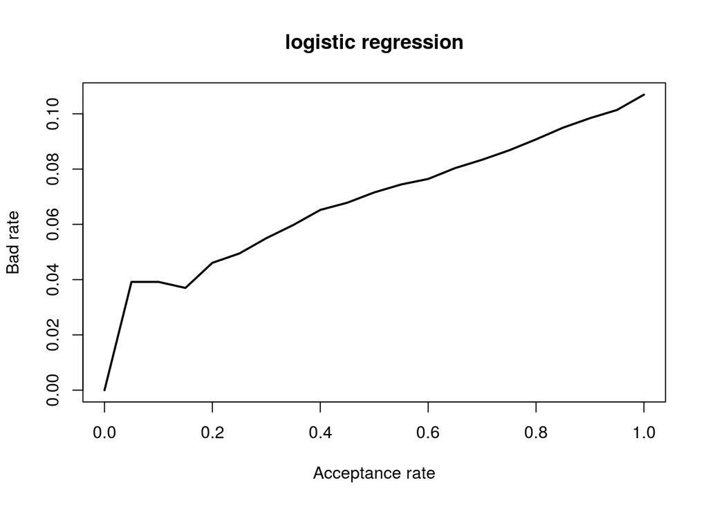

```r
##strategy_loss_matrix$table

# Plot the strategy functions
par(mfrow = c(1,1))
plot(strategy_cloglog$accept_rate, strategy_cloglog$bad_rate,
     type = "l", xlab = "Acceptance rate", ylab = "Bad rate",
     lwd = 2, main = "logistic regression")
```

```r
##plot(strategy_loss_matrix$accept_rate, strategy_loss_matrix$bad_rate,
  ##   type = "l", xlab = "Acceptance rate",
    ## ylab = "Bad rate", lwd = 2, main = "tree")
```

## To tree or not to tree?

Imagine you have 2 banks: Bank A, and Bank B. These banks are restricted to using a certain acceptance rate.

Bank A has to use an acceptance rate of 45% Bank B has to use an acceptance rate of 85% Based on the strategy tables, which model will Bank A and Bank B prefer to use?

```r
print(strategy_cloglog$table)
```

```
##       accept_rate cutoff bad_rate
##  [1,]        1.00 0.3683   0.1069
##  [2,]        0.95 0.1894   0.1014
##  [3,]        0.90 0.1808   0.0984
##  [4,]        0.85 0.1708   0.0950
##  [5,]        0.80 0.1547   0.0908
##  [6,]        0.75 0.1436   0.0868
##  [7,]        0.70 0.1380   0.0834
##  [8,]        0.65 0.1326   0.0804
##  [9,]        0.60 0.1254   0.0764
## [10,]        0.55 0.1136   0.0744
## [11,]        0.50 0.1054   0.0716
## [12,]        0.45 0.0974   0.0678
## [13,]        0.40 0.0936   0.0652
## [14,]        0.35 0.0902   0.0598
## [15,]        0.30 0.0859   0.0550
## [16,]        0.25 0.0776   0.0495
## [17,]        0.20 0.0571   0.0461
## [18,]        0.15 0.0548   0.0370
## [19,]        0.10 0.0528   0.0392
## [20,]        0.05 0.0500   0.0392
## [21,]        0.00 0.0303   0.0000
```

```r
#print(strategy_loss_matrix$table)
```

## The ROC-curve

### ROC-curves for comparison of logistic regression models

```r
# Load the pROC-package
library(pROC)
```

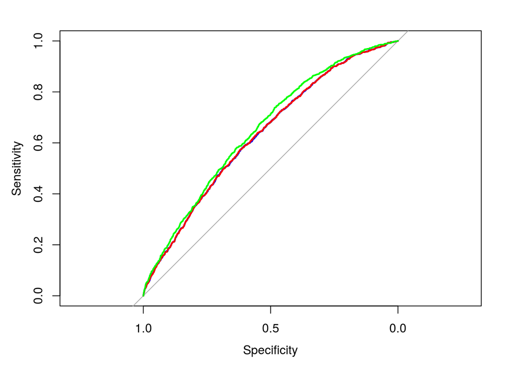

```r
# Construct the objects containing ROC-information
ROC_logit <- roc(test_set$loan_status, predictions_logit)
ROC_probit <- roc(test_set$loan_status, predictions_probit)
ROC_cloglog <- roc(test_set$loan_status, predictions_cloglog)
ROC_all_full <- roc(test_set$loan_status, predictions_all_full)

# Draw all ROCs on one plot
plot(ROC_logit)
lines(ROC_probit, col="blue")
lines(ROC_cloglog, col="red")
lines(ROC_all_full, col="green")
```

```r
# Compute the AUCs
auc(ROC_logit)
```

```
## Area under the curve: 0.6328
```

```r
auc(ROC_probit)
```

```
## Area under the curve: 0.6326
```

```r
auc(ROC_cloglog)
```

```
## Area under the curve: 0.6328
```

```r
auc(ROC_all_full)
```

```
## Area under the curve: 0.6509
```

### ROC-curves for comparison of tree-based models

[output not shown]

### Another round of pruning based on AUC

```r
# Build four models each time deleting one variable in log_3_remove_ir
log_4_remove_amnt <- glm(loan_status ~ grade + annual_inc + emp_cat,
                        family = binomial, data = training_set)
log_4_remove_grade <- glm(loan_status ~ loan_amnt + annual_inc + emp_cat, family = binomial, data = training_set)
log_4_remove_inc <- glm(loan_status ~ loan_amnt + grade + emp_cat, family = binomial, data = training_set)
log_4_remove_emp <- glm(loan_status ~ loan_amnt + grade + annual_inc, family = binomial, data = training_set)

# Make PD-predictions for each of the models
pred_4_remove_amnt <- predict(log_4_remove_amnt, newdata = test_set, type = "response")
pred_4_remove_grade <- predict(log_4_remove_grade, newdata = test_set, type = "response")
pred_4_remove_inc <- predict(log_4_remove_inc, newdata = test_set, type = "response")
pred_4_remove_emp <- predict(log_4_remove_emp, newdata = test_set, type = "response")

# Compute the AUCs
auc(test_set$loan_status, pred_4_remove_amnt)
```

```
## Area under the curve: 0.654
```

```r
auc(test_set$loan_status, pred_4_remove_grade)
```

```
## Area under the curve: 0.5888
```

```r
auc(test_set$loan_status, pred_4_remove_inc)
```

```
## Area under the curve: 0.6395
```

```r
auc(test_set$loan_status, pred_4_remove_emp)
```

```
## Area under the curve: 0.6535
```

### Further model reduction?

```r
# Build three models each time deleting one variable in log_4_remove_amnt
log_5_remove_grade <- glm(loan_status ~ annual_inc + emp_cat, family = binomial, data = training_set)
log_5_remove_inc <- glm(loan_status ~ grade  + emp_cat , family = binomial, data = training_set)
log_5_remove_emp <- glm(loan_status ~ grade + annual_inc, family = binomial, data = training_set)

# Make PD-predictions for each of the models
pred_5_remove_grade <- predict(log_5_remove_grade, newdata = test_set, type = "response")
pred_5_remove_inc <- predict(log_5_remove_inc, newdata = test_set, type = "response")
pred_5_remove_emp <- predict(log_5_remove_emp, newdata = test_set, type = "response")

# Compute the AUCs
auc(test_set$loan_status, pred_5_remove_grade)
```

```
## Area under the curve: 0.5863
```

```r
auc(test_set$loan_status, pred_5_remove_inc)
```

```
## Area under the curve: 0.6344
```

```r
auc(test_set$loan_status, pred_5_remove_emp)
```

```
## Area under the curve: 0.6537
```

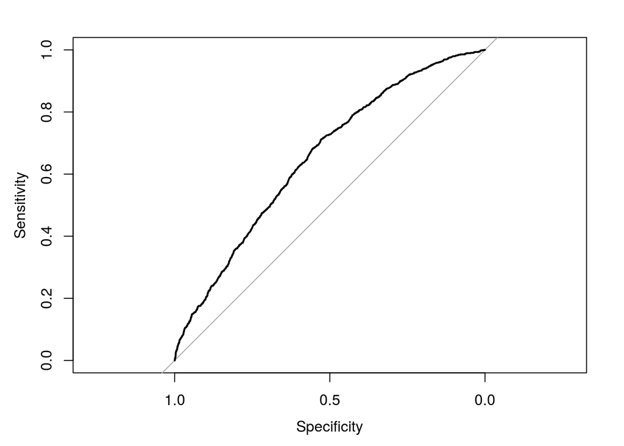

```r
# Plot the ROC-curve for the best model here
plot(roc(test_set$loan_status,pred_4_remove_amnt))
```